# Take Home Exam #1

Moriah Ruggerio

March 1, 2025

## Rules

1. Your solutions must be written up in the R Markdown (Rmd) file called `exam-01.Rmd`. This file must include your code and write up for each task. Your “submission” will be whatever is in your exam repository at the deadline. Commit and push the Rmd and the md outputs of that file.
2. This exam is open book, open internet, closed other people. You may use any online or book based resource you would like, but you must include citations for any code that you use (directly or indirectly). You **may not** consult with anyone else about this exam other than the Professor or TA for this course. You cannot ask direct questions on the internet, or consult with each other, not even for hypothetical questions.
3. You have until **[DUE DATE]** to complete this exam and turn it in via your personal Github repo - late work will **not** be accepted. Technical difficulties are **not** an excuse for late work - do not wait until the last minute to knit / commit / push.
4. Each question requires a (brief) narrative as well as a (brief) description of your approach. You can use comments in your code, but do not extensively count on these. I should be able to suppress **all** the code in your document and still be able to read and make sense of your answers. See the first setup code chunk in your Rmd file to experiment with suppressing and revealing your code.
5. Even if the answer seems obvious from the R output, make sure to state it in your narrative as well. For example, if the question is asking what is 2 + 2, and you have the following in your document, you should additionally have a sentence that states “2 + 2 is 4.”

```r
2 + 2
# 4
```

1. You may only use `tidyverse` and `nycflights13` (and its dependencies) for this assignment. Your solutions may not use any other R packages.

## Academic Integrity Statement

*I, Moriah Ruggerio, hereby state that I have not communicated with or gained information in any way from my classmates or anyone other than the Professor or TA during this exam, and that all work is my own.*

**A note on sharing / reusing code:** I am well aware that a huge volume of code is available on the web to solve any number of problems. For this exam you are allowed to make use of any online resources (e.g. StackOverflow) but you must explicitly cite where you obtained any code you directly use (or use as inspiration). You are also not allowed to ask a question on an external forum, you can only use answers to questions that have already been answered. Any recycled code that is discovered and is not explicitly cited will be treated as plagiarism. All communication with classmates is explicitly forbidden.

## Getting help

You are not allowed to post any questions on the public community repo or the public questions channel on Slack. Any questions about the exam must be asked in person in office hours or on Slack via direct message to the Professor or the TAs. For quickest response we recommend that you start a direct message with the Professor and all the TAs so that whoever gets to it first can respond to you.

## Grading and feedback

The total points for the questions add up to 90 points. The remaining 10 points are allocated to code style, commit frequency and messages, overall organization, spelling, grammar, etc. There is also an extra credit question that is worth 5 points. You will receive feedback as an issue posted to your repository, and your grade will also be recorded on Sakai.

## Logistics

Answer the questions in the document called `exam-01.Rmd`. Add your code and narrative in the spaces below each question. Add code chunks as needed. Use as many lines as you need, but keep your narrative concise.

Before completing, make sure to supress the code and look over your answers one more time. If the narrative seems sparse or choppy, edit as needed. Then, revert back to revealing your code.

Don’t forget that you will need to configure your user name and email for Git to be able to push to your repository.

## Packages

In addition to `tidyverse`, you will need the `nycflights13` package for the data. You will first need to install these packages and then load them.

```r
library(tidyverse)              #loads required packages
library(nycflights13)
```

## The data

The `nycflights13` package contains information about all flights that departed from NYC (e.g. EWR, JFK and LGA) in 2013. The main data is in the `flights` data frame, but there are additional data sets which may help understand what causes delays, specifically:

- `weather`: hourly meteorological data for each airport
- `planes`: construction information about each plane
- `airports`: airport names and locations
- `airlines`: translation between two letter carrier codes and names

## Questions

1. **Question 1 (10 points)** - What are the ten most common destinations for flights from NYC airports in 2013? Make a table that lists these in descending order of frequency and shows the number of fligts heading to each airport.

```r
flights %>%
  count(dest) %>%                 #creates frequency table for destinations
  arrange(desc(n)) %>%            #arranges from greatest to
  filter(n > 9700)                #shows only the top 10 least
```

```
## # A tibble: 10 × 2
##    dest      n
##    <chr> <int>
##  1 ORD   17283
##  2 ATL   17215
##  3 LAX   16174
##  4 BOS   15508
##  5 MCO   14082
##  6 CLT   14064
##  7 SFO   13331
##  8 FLL   12055
##  9 MIA   11728
## 10 DCA    9705
```

*I created a frequency table of the destinations of NYC flights in 2013 by using the `count()` function on the variable `dest` (destination) from the dataset `flights`. I then arranged the display from greatest to least using `arrange(desc(n))` where `n` is equal to the number of flights to a destination and filtered the data to only include values over `9700` (just under the 10th most frequent destination). (Since only the year 2013 is included in the dataset, year did not need to be separately filtered.)*

*The 10 most frequent destinations for NYC flights in 2013 in descending order are as follows: ORD (17283), ATL (17215), LAX (16174), BOS (15508), MCO (14082), CLT (14064), SFO (13331), FLL (12055), MIA (11728), and DCA (9705).*

2. **Question 2 (10 points)** - Which airlines have the most flights departing from NYC airports in 2013? Make a table that lists these in descending order of frequency and shows the number of flights for each airline. In your narrative mention the names of the airlines as well. *Hint:* You can use the `airlines` dataset to look up the airline name based on `carrier` code.

```r
#############################################
# Code Inspiration
#
# Title: R for Data Science: 19.3 Basic Joins
# Authors: Hadley Wickham, Mine Çetinkaya-Rundel, and Garrett Grolemund
# Version: 2.0
# Availibility: https://r4ds.hadley.nz/
#############################################

flights <- flights %>%
  left_join(airlines)           #adds airlines to the dataset
  #filter(is.na(name))              #checks that all carriers have a corresponding name
```

```r
flights %>%
  count(name) %>%                     #creates frequency table
  arrange(desc(n))
```

```
## # A tibble: 16 × 2
##    name                            n
##    <chr>                       <int>
##  1 United Air Lines Inc.       58665
##  2 JetBlue Airways             54635
##  3 ExpressJet Airlines Inc.    54173
##  4 Delta Air Lines Inc.        48110
##  5 American Airlines Inc.      32729
##  6 Envoy Air                   26397
##  7 US Airways Inc.             20536
##  8 Endeavor Air Inc.           18460
##  9 Southwest Airlines Co.      12275
## 10 Virgin America               5162
## 11 AirTran Airways Corporation  3260
## 12 Alaska Airlines Inc.          714
## 13 Frontier Airlines Inc.        685
## 14 Mesa Airlines Inc.            601
## 15 Hawaiian Airlines Inc.        342
## 16 SkyWest Airlines Inc.          32
```

*I first added the airline names to the `flights` dataset. To do this I used a `left.join()` to take the `name` column from `airlines` and added it to `flights`. This matched the `carrier` in `flights` to it in `airlines`. I then saved these changes to `flights` to make it accessible for later. In a separate chunk, I created a frequency table using the `count()` function. I then arranged it from greatest to least with `arrange(desc(n))`.*

*The airlines with the most flights out of NYC in 2013 are United Airlines Inc. (58,665), Jet Blue Airways (54,635), and ExpressJet Airlines Inc. (54,173).*

3. **Question 3 (10 points)** - Consider only flights that have non-missing arrival delay information. Your answer should include the name of the carrier in addition to the carrier code and the values asked.

   a. Which carrier had the highest mean arrival delay?

   *Frontier Airlines Inc. (carrier: F9) had the highest mean arrival delay of 21.92 min. (See narrative and table below)*

   b. Which carrier had the lowest mean arrival delay?

   *Alaska Airlines Inc. (carrier: AS) had the lowest mean arrival delay of -9.93 min (aka. early by a mean of 9.93 min). (See narrative and table below.)*

```r
flights %>%
  filter(!is.na(arr_delay)) %>%       #only includes data with non-missing arrival delay information
  group_by(name, carrier) %>%         #groups by airline name and includes the carrier code
  summarise(mean_arr_delay = mean(arr_delay)) %>% #takes the mean of arr_delay
  arrange(desc(mean_arr_delay))%>%       #arranges from greatest to least
  filter(mean_arr_delay > 21 | mean_arr_delay < -9)         #only displays the highest and least mean arrival delay
```

```
## # A tibble: 2 × 3
## # Groups:   name [2]
##   name                   carrier mean_arr_delay
##   <chr>                  <chr>            <dbl>
## 1 Frontier Airlines Inc. F9               21.9
## 2 Alaska Airlines Inc.   AS               -9.93
```

*First, I filtered out any rows from `flights` that were missing arrival delay information using `filter(!is.na(arr_delay))`. I then grouped the data (`group_by()`) by `name` and `carrier`. This was done to ensure that both were included in the output. Since there are not any instances with the same value for `carrier` and a different one `name` or vice versa, the data could be grouped by either (or in this case both) variables with no difference in means. Using this grouped data, I calculated the mean of `arr_delay` through the `summarise(mean())` functions and assigned the mean to the variable `mean_arr_delay`. To make the display table easier to understand, I organized the means from greatest to least with `arrange(desc(mean_arr_delay))`. I then observed the largest and smallest means (first and last rows). Finally, to clean up the output table, I filtered the data to only show the these two points by only including `mean_arr_delay` values over 21 (just below the largest mean) or under -9 (just above the smallest mean).*

4. **Question 4 (10 points)** - What was the mean temperature at the origin airport on the day with the highest departure delay? Your answer should include the name of origin airport, the date with the highest departure delay, and the mean temperature on that day.

```r
#############################################
# Code Inspiration
#
# Title: R for Data Science: 17.2.3 From individual components & 19.3.1 Mutating joins
# Authors: Hadley Wickham, Mine Çetinkaya-Rundel, and Garrett Grolemund
# Version: 2.0
# Availibility: https://r4ds.hadley.nz/datetimes.html & https://r4ds.hadley.nz/joins.html
#############################################

flights <- flights %>%
  mutate(date = make_date(year, month, day)) %>% #adds the date
  left_join(weather)                 #joins the two datasets keeping all instances of flights and adding the instances in weather that align with flights
flights %>%
  select(origin, dep_delay, date) %>% #limits output to origin, departure delay time, and the date
  arrange(desc(dep_delay)) %>%              #organizes from longest to shortest delays
#JFK on 2013-01-09 had the longest departure delay of 1301 min.
  filter(dep_delay == 1301)                 #shows only the longest departure delay
```

```
## # A tibble: 1 × 3
##   origin dep_delay date
##   <chr>      <dbl> <date>
## 1 JFK         1301 2013-01-09
```

```r
flights %>%
  group_by(origin, date) %>%         #groups by origin airport and then date
  summarise(mean_daily_temp = mean(temp)) %>% #calculates the mean daily temp for the specific airport on that day
  filter(origin == "JFK", date == "2013-01-09") #shows only the day and airport that had the longest departure delay
```

```
## # A tibble: 1 × 3
## # Groups:   origin [1]
##   origin date       mean_daily_temp
##   <chr>  <date>               <dbl>
## 1 JFK    2013-01-09            44.6
```

*To make accessing and grouping by days easier later on, I first added a new variable called `date` by combining `year`, `month`, and `day` into a date-class variable. I then added the `weather` dataset to the `flights` using a left join to keep only the weather data that had flight data that corresponded to it and saved my changes to the `flights` dataset.*

*In the next chunk I found the origin and date of the flight with the longest departure time. To do this, I first limited my output to `origin`, `dep_delay`, and `date`. Next, I organized `flights` from longest to shortest departure delay by using `arrange(desc(dep_delay))` and recorded the largest `dep_delay` value (1301). Finally, to clean up the output I filtered the data to only include the longest departure delay by using `filter(dep_delay == 1301)`. On 2013-01-09, JFK had the longest departure delay of 1301 min.*

*In my last chunk I found the average temp for the airport with the longest departure delay on that day. To do this, I grouped `flights` by `origin` and then `date` to divide the data by days and departing airport. I then calculated the mean of `temp` using the `summarise(mean())` functions. Finally, I cleaned up the table output to only show the row with the highest departure delay by filtering for `origin == "JFK"` and `date == 2013-01-09`. On 2013-01-09, JFK had the longest departure delay of 1301 min and an average temperature of 44.6 F.*

5. **Question 5 (15 points)** - Consider breaking the day into four time intervals: 12:01am-6am, 6:01am-12pm, 12:01pm-6pm, 6:01pm-12am.

   a. Calculate the proportion of flights that are delayed at departure at each of these time intervals.

```r
flights %>%
  filter(is.na(sched_dep_time))        #checks there are no flights missing a scheduled departure time
```

```
## # A tibble: 0 × 30
## # ℹ 30 variables: year <int>, month <int>, day <int>, dep_time <int>,
## #   sched_dep_time <int>, dep_delay <dbl>, arr_time <int>,
## #   sched_arr_time <int>, arr_delay <dbl>, carrier <chr>, flight <int>,
## #   tailnum <chr>, origin <chr>, dest <chr>, air_time <dbl>, distance <dbl>,
## #   hour <dbl>, minute <dbl>, time_hour <dttm>, name <chr>, date <date>,
## #   temp <dbl>, dewp <dbl>, humid <dbl>, wind_dir <dbl>, wind_speed <dbl>,
## #   wind_gust <dbl>, precip <dbl>, pressure <dbl>, visib <dbl>
```

```r
flights <-
  flights %>%
  mutate(time_interval =               #creates a new variable for the time intervals using a series of nestled if then statements
           if_else(sched_dep_time <= 600, "12:01am-6am",
                   if_else(sched_dep_time <= 1200, "6:01am-12pm",
                           if_else(sched_dep_time <= 1800, "12:01pm-6pm", "6:01pm-12am")))) %>%
  mutate(departure = if_else(dep_delay > 0, "delayed", "ontime")) #%>%    # creates a variable to store whether the flight has been delayed or not at departure
  #filter(is.na(dep_delay_or_not))     #checks why there are N/A values in dep_delay_or_not
```

```r
#############################################
# Title: R Tutorial: Counts vs. proportions
# Authors: DataCamp
#
# Availibility: https://www.youtube.com/watch?v=UCdh1sh1kos&t=121s
#############################################

delays_table <-
  table(flights$time_interval, flights$departure)  #creates a table of counts to store the data

prop.table(delays_table, 1)           #creates a frequency table of delayed flights where the rows add up to 1
```

```
##
##                 delayed    ontime
##   12:01am-6am 0.2067985 0.7932015
##   12:01pm-6pm 0.4625371 0.5374629
##   6:01am-12pm 0.2603967 0.7396033
##   6:01pm-12am 0.5195510 0.4804490
```

```r
#flights %>%                              #checks that NA values are not sneaking in to the proportion table
  #filter(!is.na(dep_delay_or_not)) %>%
  #group_by(time_interval) %>%
  #count(dep_delay_or_not)
```

*In my first chunk, I set up the time intervals (12:01am-6am, 6:01am-12pm, 12:01pm-6pm, 6:01pm-12am) as a variable, `time interval`. I first checked that `flights` had a scheduled departure time for each row by filtering all `N/A` values for `sched_dep_time`. There were no rows missing data for this variable. In a new section of code, I created a new variable `time_interval` using mutate and a series of nestled if-then statements (`if_else()`) where if `sched_dep_time` was greater than the specified time (600, 1200 and 1800 respectively) it would proceed on to the next statement. If the the time was less than or greater, however, it would assign `time_interval` to the appropriate bracket: 12:01am-6am, 6:01am-12pm, and 12:01pm-6pm respectively. Finally, if the the time was larger than all the times, it would assign it to the 6:01pm-12am interval. After the `time_interval` variable was created, I added another variable `departure`, using mutate and an `if_else()` statement. If `dep_delay` was greater than 0, then `arrival` = “delayed”. When `dep_delay` was less than or equal to 0, however, `departure` = “ontime”. I then saved these variable sections of the code to `flights` to make them accesssible in future chunks.*

*In my last chunk, I created a frequency table using proportions. I first created a table (`delays_table`) to store the counts of whether the flight was delayed or not by time interval (`time_interval` for rows and `departure` for columns). I then converted this table of counts into proportions where each row added up to 1 by using `prop.table(delays_table, 1)`.*

```
b\.
Comment on how the likelihood of being delayed change throughout the day?
```

*The later the flight is, the higher the likelihood of it being delayed. The earliest flights (12:01am-6am) had the least likelihood of being delayed (proportion of 0.21 delayed flights), followed by the 6:01am-12pm interval with a delayed flight proportion of 0.26. The latest two time intervals, 12:01pm-6pm and 6:01pm-12am, had a proportion of 0.46 and 0.52 delayed flights respectively. The likelihood of being delayed (proportion of delayed flights) follows the time of day with later times having more delayed flights than earlier.*

6. **Question 6 (15 points)** - Find the flight with the longest air time.

   a. How long is this flight?

   *This flight was 695 min or 11 hrs and 35 min. (See narrative and table below.)*

   b. What city did it fly to?

   *It flew to Honolulu, Hawaii. (See narrative and table below.)*

   c. How many seats does the plane that flew this flight have?

   *The plane that flew this flight has 292 seats. (See narrative and table below.)*

```r
#############################################
# Title: R for Data Science: 19.3.2 Specifying Join Keys
# Authors: Hadley Wickham, Mine Çetinkaya-Rundel, and Garrett Grolemund
# Version: 2.0
# Availibility: https://r4ds.hadley.nz/joins.html
#############################################

flights <-
  flights %>%
  left_join(airports, join_by(dest == faa)) %>% #attaches airports to flights, destination (in flights) is matched to the faa code
  left_join(planes, join_by(tailnum)) #%>%                  #attaches planes to flights where only planes with flight data in flights is kept
  #select(date, origin, dest, name.y, tailnum, seats)    #reduces columns to easily check that the dataset correctly attached
```

```r
flights <- flights %>%
  select(year.x : temp, time_interval : lon, tzone, seats) #restricts the amounts of columns to year.x through temp, time_interval through lon, tzone, and seats as the RAM requirements for the dataset were getting too big
```

```r
flights %>%
  select(date, air_time, dest, name.y, seats) %>% #only shows relevant variables
  arrange(desc(air_time)) %>%     #orders output from greatest to least air time
  # The flight to Honolulu on 2013-03-17 had the longest airtime of 695.
  filter(air_time == 695)         #only show the flight with the longest air time.
```

```
## # A tibble: 1 × 5
##   date       air_time dest  name.y        seats
##   <date>        <dbl> <chr> <chr>         <int>
## 1 2013-03-17      695 HNL   Honolulu Intl   292
```

*In my first chunk I attached both of the necessary datasets, `airports` and `planes`, to the the main dataset, `flights`. I used a `left_join` for each to make sure to only keep `airport` and `plane` data for rows that we had flight data on. However, for both datasets I had to manually set the join key using `join_by()`. For `airports` I specified that `dest == faa`. This matched `faa` (the airport code) to the destination airport code in `flights`. For planes, I set the key to `tailnum` since it was automatically using `year` which means 2 different things in the datasets. In `flights` it is the year of the flight, but in `planes` it is the year the plane was made. `Tailnum`, however, is in both datasets and references the same thing.*

*In my final chunk, I determined the flight with the longest airtime, found the destination, and determined the number of seats on the flight. I first selected only `date`, `air_time`, `dest`, `name.y` (name of the airport), and `seats` from `flights` to keep my output clean. I then arranged the data from greatest to least by air_time to determine the flight with the longest air_time. The flight to Honolulu on 2013-03-17 had the longest airtime of 695 min (or 11 hr 35 min). Finally, I limited my table output to only show this flight by filtering for data with an `air_time` of 695.*

*After I reached question 8, I added another chunk in the middle to reduce the amount of variables in `flights` as the dataset was getting too large for my computer. I selected only the necessary columns (restricts the amounts of columns to (`year.x` through `temp`, `time_interval` through `lon`, `tzone`, and `seats`) from `flights`. I then saved over `flights` to reduce the variable count from 47 to 29.*

7. **Question 7 (15 pts)** - The `airports` data frame contains information on a large number of primarily American airports. These data include location information for these airports in the form of latitude and longitude coordinates. In this question we limit our focus to the [Contiguous United States](https://en.wikipedia.org/wiki/Contiguous_United_States). Visualize and describe the distribution of the longitudes of airports in the Contiguous United States. What does this tell you about the geographical distribution of these airports? *Hint:* You will first need to limit your analysis to the Contiguous United States. [This Wikipedia article](https://en.wikipedia.org/wiki/List_of_extreme_points_of_the_United_States) can help, but you’re welcomed to use other resources as well. Make sure to cite whatever resource you use.

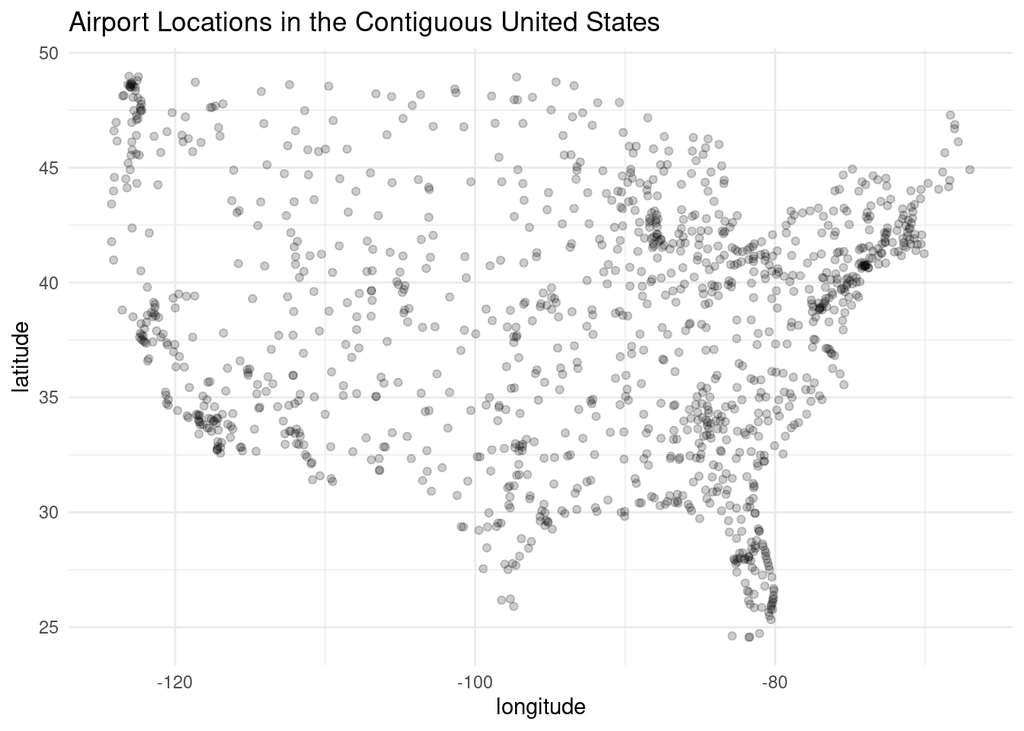

```r
airports %>%
  filter(lat < 49.2304, lat > 24.3119,  # only includes data with latitudes between the northernmost point (Northwest Angle Inlet, MN) and the southernmost point (Ballast Key, FL) in the contiguous US (Wikipedia contributers, 2025)
          lon < 66.56493, lon > -124.46181) %>% # only includes data with longitudes between the easternmost point (Sail Rock, Lubec, ME) and the westernmost point (Bodelteh Islands,  Cape Alava, WA) in the contiguous US (Wikipedia contributers, 2025)

  #filter(lat > 49.2304 | lat < 24.3119,
          #lon > 66.56493 | lon < -124.46181) %>% #Checks that none of the excluded points are part of the contiguous US
  #count(tzone)                    #condenses into time/zones to check all are within the contiguous US
  ggplot(mapping = aes(x = lon, y = lat)) +
  geom_point(alpha = 0.20) +
  labs(title = "Airport Locations in the Contiguous United States", y = "latitude", x = "longitude") +
  theme_minimal()
```

*Based on the visualization, most airports appear to be spread throughout the eastern half of the United States. However, there enough airports distributed throughout most of the contigous US that one can see the shape of the contiguous US (Maine, Vermont, and New Hampshire however, get lost). There are a few areas with a lot of overlapping airport locations. These appear to be primarily coastal or nearby a waterway. This includes airports in Florida, California, Washington state, Great Lakes region, and the Northern East Coast.*

**Longitude and Latitude coordinates for the Contiguous US:** Wikipedia contributors. (2025, February 22). List of extreme points of the United States. *Wikipedia, The Free Encyclopedia.* Retrieved February 25, 2025, from https://en.wikipedia.org/w/index.php?title=List_of_extreme_points_of_the_United_States&oldid=1277027586*

*For the visualization, I created a scatterplot of the filtered data. I used `ggplot()` where the asthetics of x and y were mapped to `lon` (longitude) and `lat` (latitude) respectively. I then added `geom_point()` (plots as a scatterplot) and fixed the alpha level to equal 0.20 to allow for overlapping points to be seen. Finally, I added labels (title = “Airport Locations in the Contiguous United States”, y = “latitude”, x = “longitude”) using `labs()` and made the theme minimal (`theme_minimal`).*

8. **Question 8 (15 pts)** - Recreate the plot included below using the `flights` data. Once you have created the visualization, in no more than one paragraph, describe what you think the point of this visualization might be. *Hint:* The visualization uses the variable `arrival`, which is not included in the `flights` data frame. You will have to create `arrival` yourself, it is a categorical variable that is equal to `"ontime"` when `arr_delay <= 0` and `"delayed"` when `arr_delay > 0`.

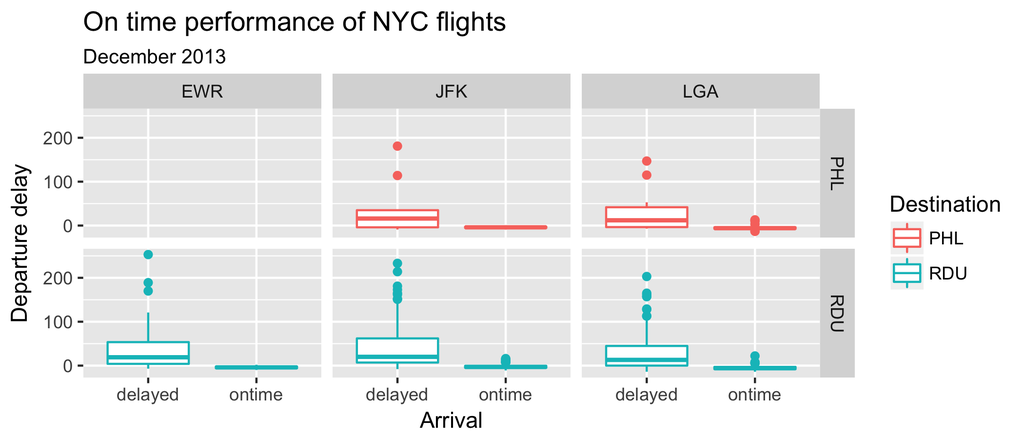

```r
flights <- flights %>%
  mutate(arrival = if_else(arr_delay > 0, "delayed", "ontime")) #%>%    # creates a variable to store whether the flight has been delayed or not)
```

```r
#flights %>%
  #filter(date >= ymd (20131201)) %>%
  #filter(dest == "BWI")                  #checks that other significant airports within the lat and lon had flights in december

#airports %>%
 # filter(lat < 39.87194, lat > 35.87764,
          #lon < -75.24114, lon > -78.78747)


#airports %>%
  #filter(faa == "PHL" | faa == "RDU")
```

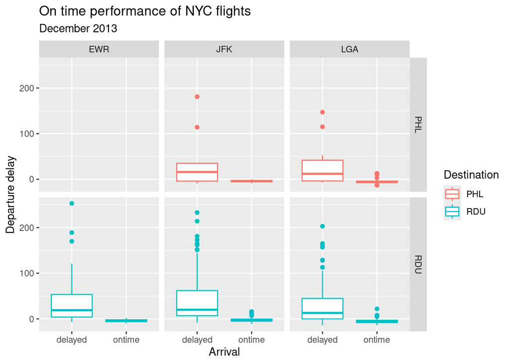

```r
flights %>%
  filter(dest == "PHL" | dest == "RDU",   #only includes destinations of PHL and RDU
         date >= ymd (20131201),          #only includes December
         !is.na(arrival)) %>%             #removes na arrivals
  ggplot(mapping = aes(x = arrival, y = dep_delay, color = dest)) +
  geom_boxplot() +
  labs(title = "On time performance of NYC flights", subtitle = "December 2013", color = "Destination", y = "Departure delay", x = "Arrival") +
  facet_grid(dest ~ origin)
```

*In my first chunk I added the variable `arrival` to the `flights` dataset using `mutate` and a nested `if_else` statement. If `arr_delay` (arrival delay) was greater than 0, `arrival` = “delayed”. Else, (`arr_delay` <= 0) `arrival` = “ontime”.*

*In my last chunk, I created the visualization. I first filtered the data to remove N/A arrivals with (`!na.rm(arrival)`), only included “PHL” or “RDU” as destinations (`dest == "PHL" | dest == "RDU"`), and only include December by only including dates on or after December 1st (`date >= ymd (20131201)`). I then used `ggplot()` to map the aesthetics of `arrival` on the x-axis, `dep_delay` (departure delays) on the y, and the color to `dest` (destination). I then made the plot a box and whisker plot by adding `geom_box()`, and added labels by adding labs. I set the title to equal “On time performance of NYC flights”, the subtitle to equal “December 2013”, the color to be “Destination”, the y-axis label to be “Departure delay”, and the x-axis label to equal “Arrival”. Finally, I added `facet_grid(dest ~ origin)` to facet the box and whisker plot into a grid where origin was on the x-axis and destination was on the y-axis.*

*The purpose of this graph likely has to do with comparing the frequency and length of delays from the NYC airports (EWR, JFK, LGA) to (PHL and RDU) through the month of December 2013. December is one of the most frequent airtravel months due to Christmas, but also has a lot of inclement weather and therefore delays. It might be helpful in choosing which departing airport one would want to use during this month to best avoid delays as you can compare the distributions of ontime and delayed arrivals. It also could help give an estimation of the length of departure delays (and therefore the amount of time you’ll likely be waiting) for each of the airports to the destination.*

**Extra Credit (5 pts)** - Create a visualization that effectively shows if there is a relationship between the average daily departure delay and the average daily temperature for all three New York city airports. Your answer must be given in a single pipe. (You should only spend time on this question once you have finished answering the others)

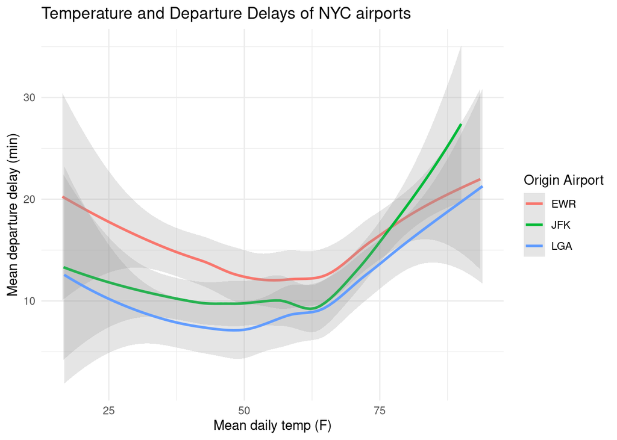

```r
flights %>%
  filter(!is.na(temp), !is.na(dep_delay)) %>% #removes N/A temps and departure delays
  group_by(origin, date) %>%         #groups by origin airport and then date
  summarise(mean_daily_temp = mean(temp), mean_dep_delay = mean(dep_delay)) %>%
  ggplot(mapping = aes(x = mean_daily_temp, y = mean_dep_delay, color = origin)) +
  #geom_point(alpha = 0.20) +
  geom_smooth(alpha = 0.25) +
  labs(title = "Temperature and Departure Delays of NYC airports", x = "Mean daily temp (F)", y = "Mean departure delay (min)", color = "Origin Airport") +
  theme_minimal()
```

*From the visualization we can see that, for each airport, the daily average departure delay does correlate to the average daily temperature. When temps are lower (less than 50 F), the average departure delay for the airport, tends to be higher. When temps are high (greater than 60 F), however, daily departure delays also increase (especially for JFK). Between 50 and 60 F, daily departure delays are roughly level or slowly increasing.*